# CompteRenduTP3_OpinionMining

### Compte Rendu TP3 - Opinion Mining

##### Elaboré par :

Youssef Skouri  
Baha Khayati  
Taysir Fattoumi

## Problématique:

Le mouvement des Gilets jaunes est apparu en France en octobre 2018 et s'est étendu dans de moindres proportions à d’autres pays. Ce mouvement social spontané trouve son origine dans la diffusion sur les réseaux sociaux d’appels à manifester.

Les réseaux sociaux sont désormais un outil important afin de mener une guerre d’influence. On le voit notamment dans la crise actuelle et la révolte des Gilets jaunes. Selon une étude de Metricool, l’activité sur les réseaux sociaux associée aux thématiques touchant au mouvement des #GiletsJaunes monte en puissance quotidiennement.

Il y a déjà plusieurs semaines que le hashtag #GiletsJaunes est très actif sur les réseaux sociaux. Le réseau social qui accumule le plus de contenu, de conversation et d’interaction sur ce sujet est de loin Twitter suivi de Facebook.

```python
from IPython.display import HTML,display
display(HTML("<table><tr><td><img src='img1.png'></td><td><img src='img2.png'></td></tr></table>"))
```

[output not shown]

# Solution proposée:

Vu que ce mouvement est issus principalement des réseaux sociaux, il serait donc très pértient d'étudier les données issues de ces réseaux dans le but d'extraire l'opinion des internautes à propos de ce phénomene. Dans notre cas, nous avons été fournis d'un dataset contenant une cinquentaine de tweets, nous commençerons donc par les étudier afin d'en extraire l'opinion des gens sur la situation actuelle en France.

```python
import pandas as pd
import numpy as np
import matplotlib.pyplot as plt
```

# I - Data Preparation

```python
df=pd.read_csv("giletjaune.csv", sep = ',', encoding='ISO 8859-1')
df.head()
```

|  | Date-Time | Twitter handle | Pleasure | Arousal | Tweet | sentiment |
| --- | --- | --- | --- | --- | --- | --- |
| 0 | 12-03-18 07:30,10thCrusader,5.64,4.64,"By the ... | NaN | NaN | NaN | NaN | NaN |
| 1 | 12-01-18 18:46,AhmedTarekMokh1,6.52,4.30,"RT @... | NaN | NaN | NaN | NaN | NaN |
| 2 | 12-02-18 00:46,AlfArthur8,6.47,4.42,@GuyVerhof... | NaN | NaN | NaN | NaN | NaN |
| 3 | 12-03-18 23:20,alicnsuna,5.24,5.52,RT @joepenn... | NaN | NaN | NaN | NaN | NaN |
| 4 | 12-04-18 01:06,alown6666,5.60,4.14,"@RusoAzul ... | NaN | NaN | NaN | NaN | NaN |

```python
df_split = df["Date-Time"].str.split(",", n = 10, expand = True)
df_split
```

|  | 0 | 1 | 2 | 3 | 4 | 5 | 6 | 7 | 8 | 9 |
| --- | --- | --- | --- | --- | --- | --- | --- | --- | --- | --- |
| 0 | 12-03-18 07:30 | 10thCrusader | 5.64 | 4.64 | "By the time Petit Macron gets back to Paris | he'll be browning his trousers | Neutral; | None | None | None |
| 1 | 12-01-18 18:46 | AhmedTarekMokh1 | 6.52 | 4.30 | "RT @Keziadventure: Quick visit to the #ArcDeT... | most #GiletJaune protestors seemed very peace... | young people and even dogs. #livecoverage #bb... | Positive; | None | None |
| 2 | 12-02-18 00:46 | AlfArthur8 | 6.47 | 4.42 | @GuyVerhoftwat Good time for @MayorofLondon to... | None | None | None | None | None |
| 3 | 12-03-18 23:20 | alicnsuna | 5.24 | 5.52 | RT @joepenney: #GiletJaune protestors beating ... | Negative; | None | None | None | None |
| 4 | 12-04-18 01:06 | alown6666 | 5.60 | 4.14 | "@RusoAzul It was more like a contract between... | and giletJaune left the place..." | Negative; | None | None | None |
| 5 | 12-03-18 07:53 | andrew_ed_ba | 5.83 | 3.86 | "As part francophone | way to make the #GiletJaune movement look lik... | but also effectively damaging historical sites. | Negative; | None | None |
| 6 | 12-04-18 11:07 | Viva la @EmmanuelMacron indeed." | Positive; | None | None | None | None | None | None | None |
| 7 | 12-04-18 02:54 | Antibullshit12 | 5.07 | 4.54 | "RT @Antibullshit12: 1/3 The Battle For Paris!... | Negative; | None | None | None | None |
| 8 | 12-04-18 02:54 | Antibullshit12 | 5.07 | 4.54 | "RT @Antibullshit12: 2/3 The Battle For Paris!... | Negative; | None | None | None | None |
| 9 | 12-02-18 17:31 | AxelHuynh | 4.69 | 4.45 | "TODAY | A SYMBOL OF REPUBLIC & FREEDOM HAS BEEN STAINED | Positive; | None | None | None |
| 10 | 12-02-18 06:07 | ITâS SO SAD & REVOLTING! DONâT LET IGNORAN... | France https://t.co/lzjuD9djVQ" | Negative; | None | None | None | None | None | None |
| 11 | 12-02-18 06:56 | bizcom | 6.37 | 4.22 | Hi @NATO could you confirm this guy is member ... | Negative; | None | None | None | None |
| 12 | 12-03-18 04:49 | bursuk | 5.07 | 4.54 | "RT @TickT0Tack: 1/3 The Battle For Paris! Yel... | Negative; | None | None | None | None |
| 13 | 12-03-18 01:18 | CarstenGerhardt | 6.01 | 4.08 | Poweful stuff going on in France ð® #GiletJaune | Positive; | None | None | None | None |
| 14 | 12-03-18 14:23 | cdeysson | 5.55 | 4.91 | "The point of theÂ gilet jauneÂ is to ensure i... | theÂ gilets jaunesÂ have won in terms of what... | Positive; | None | None | None |
| 15 | 12-03-18 22:37 | charmgritty | 6.29 | 4.75 | "Imagine a world | dear reader | where the most woke celebrity take from the #... | Negative; | None | None |
| 16 | 12-04-18 05:35 | clinicalwstmn | 5.09 | 5.21 | "@DoctorKropotkin @BethLynch2020 @VryKranky Mi... | Negative "; | None | None | None | None |
| 17 | 12-03-18 09:13 | DelightOxygen | 5.96 | 4.55 | "Also the antifas on this video trying to hack... | when in the first time they said us to ""go f... | Negative; | None | None | None |
| 18 | 12-02-18 17:12 | DickyDido3 | 5.81 | 4.68 | "@allan_clarke_ @Souria4Syrians C'mon | SJW | do you really think these GiletJaune fucks ar... | Negative; | None | None |
| 19 | 12-02-18 17:07 | Let me ask you a question: what are they 'prot... | Neutral; | None | None | None | None | None | None | None |
| 20 | 12-03-18 23:43 | dominic_putney | 5.12 | 3.97 | @Michael_Heaver The continent is watching as @... | Positive; | None | None | None | None |
| 21 | 12-02-18 01:26 | donnypongo | 5.10 | 4.93 | "RT @EHSANI22: Many demonstrators in #Paris sa... | Negative; | None | None | None | None |
| 22 | 12-02-18 08:07 | âI came peacefully | but even Iâm ready to fight given how Iâv... | a 67-year-old retired army commander #GiletJa... | Negative; | None | None | None | None | None |
| 23 | 12-03-18 09:20 | duyquykaka | 4.38 | 5.00 | I liked a @YouTube video https://t.co/klkRPKQj... | Neutral; | None | None | None | None |
| 24 | 12-01-18 16:55 | e_connaisseur | 5.70 | 3.23 | #WorldAIDSDay #AIDS #ActUp #Paris #PlaceDeLaCo... | Positive; | None | None | None | None |
| 25 | 12-01-18 20:46 | edith_fr | 5.79 | 4.20 | "RT @HeloisePatricia: I almost feel sorry for ... | and the first person to greet him is wearing ... | Negative; | None | None | None |
| 26 | 12-03-18 20:20 | elephantsshoes | 5.65 | 4.29 | "RT @Ghrissiha: â¬ If there is no bread for t... | Posistive; | None | None | None | None |
| 27 | 12-04-18 03:57 | feliks712 | 5.71 | 5.44 | "RT @Unjum_Mirza: #Metro this morning: #France... | Negative"; | None | None | None | None |
| 28 | 12-02-18 15:19 | FiatPalioHLX | 5.74 | 4.35 | "RT @StrategicNews1: I do not express my point... | although I support the commendable cause of #... | I find it more than shameful to tag the #ArcD... | Positive; | None | None |
| 29 | 12-01-18 19:18 | GadaldiGiovanni | 4.87 | 4.97 | Guys donât worry while all the demonstration... | Positive; | None | None | None | None |
| 30 | 12-03-18 06:39 | Ghrissiha | 5.30 | 4.71 | "Is it a spontaneous popular movement | or is it a transient crisis because of Mr. #M... | Neutral; | None | None | None |
| 31 | 12-02-18 10:07 | Is #France a prelude to major changes? Is the ... | Negative; | None | None | None | None | None | None | None |
| 32 | 12-02-18 20:01 | GingerMcFall | 5.81 | 3.73 | "RT @BrunoBoelpaep: About a hundred yellow ves... | heading to Brussels Central Station | Neutral; | None | None | None |
| 33 | 12-02-18 19:07 | Une centaine de gilets jaunes en route de Cong... | Neutral; | None | None | None | None | None | None | None |
| 34 | 12-01-18 20:27 | GingerMcFall | 6.30 | 3.52 | RT @Blackblocfr: Follow us on Facebook #GiletJ... | Neutral; | None | None | None | None |
| 35 | 12-02-18 16:19 | âMacronâs new levies on fossil fuels | [...] to cut emissions & to fund renewable en... | triggered riots.â | Neutral; | None | None | None | None | None |
| 36 | 12-03-18 18:51 | harrycliffjr | 5.08 | 5.71 | RT @harrycliffjr: YELLOWFEVER? #music :HCJR #m... | Negative ; | None | None | None | None |
| 37 | 12-03-18 23:44 | hilalgulumcan | 6.03 | 4.20 | "RT @marklowen: #Turkeyâs @MFATurkey issues ... | adding âwe believe in the necessity of dial... | Negative; | None | None | None |
| 38 | 12-01-18 22:33 | humanbird19 | 6.03 | 4.46 | Our police our swats are exhausted 15 hours wi... | Negative; | None | None | None | None |
| 39 | 12-01-18 20:11 | hw_renewe | 5.99 | 4.44 | "When Macron disembarked from his jet | rather than being met w a sea of diplomats & ... | he instead shook hands with what appeared to ... | Neutral" | None | None |
| 40 | 12-02-18 23:00 | ibonnetb | 5.38 | 4.29 | "About 100 | 000 âGilets jaunesâ protested yesterday in... | stores vandalized and the Arc de Triomphe sto... | the symbol of the French Republic | was smashed. #giletjaune #giletsjaunes #franc... | Negative; |
| 41 | 12-03-18 00:56 | ikbenbezorgd | 3.94 | 3.70 | "RT @Dwalingen: It is clear.The government is ... | Negative; | None | None | None | None |
| 42 | 12-02-18 03:58 | j_amorfati | 5.07 | 4.54 | "RT @Antibullshit12: The Battle For Paris! Yel... | Negative; | None | None | None | None |
| 43 | 12-03-18 02:32 | Jabato111111 | 5.22 | 4.63 | "RT @ClimatismBlog: AWW no good! #JeuDePaume o... | Negative; | None | None | None | None |
| 44 | 12-01-18 17:36 | jamesinparis | 5.65 | 5.14 | "This guy is too ridiculous for words | Negative; | None | None | None | None |
| 45 | 12-02-18 13:34 | javibrantiuk | 3.33 | 4.18 | One Dead Following Accident at 'Yellow Vest' R... | Negative; | None | None | None | None |
| 46 | 12-02-18 02:27 | JJDreau | 6.52 | 5.46 | "Instant #karma Justice immanente | Positive; | None | None | None | None |
| 47 | 12-02-18 17:22 | johndunet | 6.13 | 3.33 | "@KatieMcCoy101 all eyes on us | don't worry | we will not disappoint you #YellowVests #Gile... | Positive; | None | None |
| 48 | 12-02-18 10:25 | Johnfrededdy | 6.74 | 5.42 | "RT @Sligogirls: #giletjaune ""Workers' no lon... | giving rise to a social and cultural shock"" ... | Negative; | None | None | None |
| 49 | 12-04-18 03:33 | jotahal | 5.42 | 4.97 | "RT @r_karahasanoglu: Where is the global media | national media and the European Union? #gilet... | Negative; | None | None | None |
| 50 | 12-04-18 03:33 | #ViveLaDÃ©mocratieFrancaises ð https://t.co... | Positive; | None | None | None | None | None | None | None |

```python
df.loc[1,'Date-Time'].split(',')
```

```
['12-01-18 18:46',
 'AhmedTarekMokh1',
 '6.52',
 '4.30',
 '"RT @Keziadventure: Quick visit to the #ArcDeTriomphe today turned into an even quicker one. Huge police presence',
 ' most #GiletJaune protestors seemed very peaceful. Lots of women',
 ' young people and even dogs. #livecoverage #bbcnews #paris https://t.co/pG9F5Q73uE"',
 'Positive;']
```

```python
sentiments=[]
tweets=[]
tweet_sent=pd.DataFrame(['sentiment', 'Tweet'])
for index, row in df_split.iterrows():
    j=9
    while (j>0):
        if (row[j]is not None):
            sentiments.append(row[j])
            tw=""
            j-=1
            while (any(c.isalpha() for c in row[j])):
                tw=row[j]+tw
                j-=1
            tweets.append(tw)
            break
        j-=1
```

```python
sentiments
tweets
df = pd.DataFrame({'Tweet':tweets, 'Sentiment':sentiments})
df
```

|  | Tweet | Sentiment |
| --- | --- | --- |
| 0 | "By the time Petit Macron gets back to Paris h... | Neutral; |
| 1 | "RT @Keziadventure: Quick visit to the #ArcDeT... | Positive; |
| 2 |  | @GuyVerhoftwat Good time for @MayorofLondon to... |
| 3 | RT @joepenney: #GiletJaune protestors beating ... | Negative; |
| 4 | "@RusoAzul It was more like a contract between... | Negative; |
| 5 | "As part francophone way to make the #GiletJau... | Negative; |
| 6 | Viva la @EmmanuelMacron indeed." | Positive; |
| 7 | "RT @Antibullshit12: 1/3 The Battle For Paris!... | Negative; |
| 8 | "RT @Antibullshit12: 2/3 The Battle For Paris!... | Negative; |
| 9 | "TODAY A SYMBOL OF REPUBLIC & FREEDOM HAS BEEN... | Positive; |
| 10 | ITâS SO SAD & REVOLTING! DONâT LET IGNORAN... | Negative; |
| 11 | Hi @NATO could you confirm this guy is member ... | Negative; |
| 12 | "RT @TickT0Tack: 1/3 The Battle For Paris! Yel... | Negative; |
| 13 | Poweful stuff going on in France ð® #GiletJaune | Positive; |
| 14 | "The point of theÂ gilet jauneÂ is to ensure i... | Positive; |
| 15 | "Imagine a world dear reader where the most wo... | Negative; |
| 16 | "@DoctorKropotkin @BethLynch2020 @VryKranky Mi... | Negative "; |
| 17 | "Also the antifas on this video trying to hack... | Negative; |
| 18 | "@allan_clarke_ @Souria4Syrians C'mon SJW do y... | Negative; |
| 19 | Let me ask you a question: what are they 'prot... | Neutral; |
| 20 | @Michael_Heaver The continent is watching as @... | Positive; |
| 21 | "RT @EHSANI22: Many demonstrators in #Paris sa... | Negative; |
| 22 | âI came peacefully but even Iâm ready to f... | Negative; |
| 23 | I liked a @YouTube video https://t.co/klkRPKQj... | Neutral; |
| 24 | #WorldAIDSDay #AIDS #ActUp #Paris #PlaceDeLaCo... | Positive; |
| 25 | "RT @HeloisePatricia: I almost feel sorry for ... | Negative; |
| 26 | "RT @Ghrissiha: â¬ If there is no bread for t... | Posistive; |
| 27 | "RT @Unjum_Mirza: #Metro this morning: #France... | Negative"; |
| 28 | "RT @StrategicNews1: I do not express my point... | Positive; |
| 29 | Guys donât worry while all the demonstration... | Positive; |
| 30 | "Is it a spontaneous popular movement or is it... | Neutral; |
| 31 | Is #France a prelude to major changes? Is the ... | Negative; |
| 32 | "RT @BrunoBoelpaep: About a hundred yellow ves... | Neutral; |
| 33 | Une centaine de gilets jaunes en route de Cong... | Neutral; |
| 34 | RT @Blackblocfr: Follow us on Facebook #GiletJ... | Neutral; |
| 35 | âMacronâs new levies on fossil fuels [...]... | Neutral; |
| 36 | RT @harrycliffjr: YELLOWFEVER? #music :HCJR #m... | Negative ; |
| 37 | "RT @marklowen: #Turkeyâs @MFATurkey issues ... | Negative; |
| 38 | Our police our swats are exhausted 15 hours wi... | Negative; |
| 39 | "When Macron disembarked from his jet rather t... | Neutral" |
| 40 | "About 100000 âGilets jaunesâ protested ye... | Negative; |
| 41 | "RT @Dwalingen: It is clear.The government is ... | Negative; |
| 42 | "RT @Antibullshit12: The Battle For Paris! Yel... | Negative; |
| 43 | "RT @ClimatismBlog: AWW no good! #JeuDePaume o... | Negative; |
| 44 | "This guy is too ridiculous for words | Negative; |
| 45 | One Dead Following Accident at 'Yellow Vest' R... | Negative; |
| 46 | "Instant #karma Justice immanente | Positive; |
| 47 | "@KatieMcCoy101 all eyes on us don't worry we ... | Positive; |
| 48 | "RT @Sligogirls: #giletjaune ""Workers' no lon... | Negative; |
| 49 | "RT @r_karahasanoglu: Where is the global medi... | Negative; |
| 50 | #ViveLaDÃ©mocratieFrancaises ð https://t.co... | Positive; |

```python
df['Tweet'][2]=df['Sentiment'][2]
df['Sentiment'][2]="Neutral;"
df
```

|  | Tweet | Sentiment |
| --- | --- | --- |
| 0 | "By the time Petit Macron gets back to Paris h... | Neutral; |
| 1 | "RT @Keziadventure: Quick visit to the #ArcDeT... | Positive; |
| 2 | @GuyVerhoftwat Good time for @MayorofLondon to... | Neutral; |
| 3 | RT @joepenney: #GiletJaune protestors beating ... | Negative; |
| 4 | "@RusoAzul It was more like a contract between... | Negative; |
| 5 | "As part francophone way to make the #GiletJau... | Negative; |
| 6 | Viva la @EmmanuelMacron indeed." | Positive; |
| 7 | "RT @Antibullshit12: 1/3 The Battle For Paris!... | Negative; |
| 8 | "RT @Antibullshit12: 2/3 The Battle For Paris!... | Negative; |
| 9 | "TODAY A SYMBOL OF REPUBLIC & FREEDOM HAS BEEN... | Positive; |
| 10 | ITâS SO SAD & REVOLTING! DONâT LET IGNORAN... | Negative; |
| 11 | Hi @NATO could you confirm this guy is member ... | Negative; |
| 12 | "RT @TickT0Tack: 1/3 The Battle For Paris! Yel... | Negative; |
| 13 | Poweful stuff going on in France ð® #GiletJaune | Positive; |
| 14 | "The point of theÂ gilet jauneÂ is to ensure i... | Positive; |
| 15 | "Imagine a world dear reader where the most wo... | Negative; |
| 16 | "@DoctorKropotkin @BethLynch2020 @VryKranky Mi... | Negative "; |
| 17 | "Also the antifas on this video trying to hack... | Negative; |
| 18 | "@allan_clarke_ @Souria4Syrians C'mon SJW do y... | Negative; |
| 19 | Let me ask you a question: what are they 'prot... | Neutral; |
| 20 | @Michael_Heaver The continent is watching as @... | Positive; |
| 21 | "RT @EHSANI22: Many demonstrators in #Paris sa... | Negative; |
| 22 | âI came peacefully but even Iâm ready to f... | Negative; |
| 23 | I liked a @YouTube video https://t.co/klkRPKQj... | Neutral; |
| 24 | #WorldAIDSDay #AIDS #ActUp #Paris #PlaceDeLaCo... | Positive; |
| 25 | "RT @HeloisePatricia: I almost feel sorry for ... | Negative; |
| 26 | "RT @Ghrissiha: â¬ If there is no bread for t... | Posistive; |
| 27 | "RT @Unjum_Mirza: #Metro this morning: #France... | Negative"; |
| 28 | "RT @StrategicNews1: I do not express my point... | Positive; |
| 29 | Guys donât worry while all the demonstration... | Positive; |
| 30 | "Is it a spontaneous popular movement or is it... | Neutral; |
| 31 | Is #France a prelude to major changes? Is the ... | Negative; |
| 32 | "RT @BrunoBoelpaep: About a hundred yellow ves... | Neutral; |
| 33 | Une centaine de gilets jaunes en route de Cong... | Neutral; |
| 34 | RT @Blackblocfr: Follow us on Facebook #GiletJ... | Neutral; |
| 35 | âMacronâs new levies on fossil fuels [...]... | Neutral; |
| 36 | RT @harrycliffjr: YELLOWFEVER? #music :HCJR #m... | Negative ; |
| 37 | "RT @marklowen: #Turkeyâs @MFATurkey issues ... | Negative; |
| 38 | Our police our swats are exhausted 15 hours wi... | Negative; |
| 39 | "When Macron disembarked from his jet rather t... | Neutral" |
| 40 | "About 100000 âGilets jaunesâ protested ye... | Negative; |
| 41 | "RT @Dwalingen: It is clear.The government is ... | Negative; |
| 42 | "RT @Antibullshit12: The Battle For Paris! Yel... | Negative; |
| 43 | "RT @ClimatismBlog: AWW no good! #JeuDePaume o... | Negative; |
| 44 | "This guy is too ridiculous for words | Negative; |
| 45 | One Dead Following Accident at 'Yellow Vest' R... | Negative; |
| 46 | "Instant #karma Justice immanente | Positive; |
| 47 | "@KatieMcCoy101 all eyes on us don't worry we ... | Positive; |
| 48 | "RT @Sligogirls: #giletjaune ""Workers' no lon... | Negative; |
| 49 | "RT @r_karahasanoglu: Where is the global medi... | Negative; |
| 50 | #ViveLaDÃ©mocratieFrancaises ð https://t.co... | Positive; |

## Extracted Tweets and Sentiments

```python
df
```

|  | Tweet | Sentiment |
| --- | --- | --- |
| 0 | "By the time Petit Macron gets back to Paris h... | Neutral; |
| 1 | "RT @Keziadventure: Quick visit to the #ArcDeT... | Positive; |
| 2 | @GuyVerhoftwat Good time for @MayorofLondon to... | Neutral; |
| 3 | RT @joepenney: #GiletJaune protestors beating ... | Negative; |
| 4 | "@RusoAzul It was more like a contract between... | Negative; |
| 5 | "As part francophone way to make the #GiletJau... | Negative; |
| 6 | Viva la @EmmanuelMacron indeed." | Positive; |
| 7 | "RT @Antibullshit12: 1/3 The Battle For Paris!... | Negative; |
| 8 | "RT @Antibullshit12: 2/3 The Battle For Paris!... | Negative; |
| 9 | "TODAY A SYMBOL OF REPUBLIC & FREEDOM HAS BEEN... | Positive; |
| 10 | ITâS SO SAD & REVOLTING! DONâT LET IGNORAN... | Negative; |
| 11 | Hi @NATO could you confirm this guy is member ... | Negative; |
| 12 | "RT @TickT0Tack: 1/3 The Battle For Paris! Yel... | Negative; |
| 13 | Poweful stuff going on in France ð® #GiletJaune | Positive; |
| 14 | "The point of theÂ gilet jauneÂ is to ensure i... | Positive; |
| 15 | "Imagine a world dear reader where the most wo... | Negative; |
| 16 | "@DoctorKropotkin @BethLynch2020 @VryKranky Mi... | Negative "; |
| 17 | "Also the antifas on this video trying to hack... | Negative; |
| 18 | "@allan_clarke_ @Souria4Syrians C'mon SJW do y... | Negative; |
| 19 | Let me ask you a question: what are they 'prot... | Neutral; |
| 20 | @Michael_Heaver The continent is watching as @... | Positive; |
| 21 | "RT @EHSANI22: Many demonstrators in #Paris sa... | Negative; |
| 22 | âI came peacefully but even Iâm ready to f... | Negative; |
| 23 | I liked a @YouTube video https://t.co/klkRPKQj... | Neutral; |
| 24 | #WorldAIDSDay #AIDS #ActUp #Paris #PlaceDeLaCo... | Positive; |
| 25 | "RT @HeloisePatricia: I almost feel sorry for ... | Negative; |
| 26 | "RT @Ghrissiha: â¬ If there is no bread for t... | Posistive; |
| 27 | "RT @Unjum_Mirza: #Metro this morning: #France... | Negative"; |
| 28 | "RT @StrategicNews1: I do not express my point... | Positive; |
| 29 | Guys donât worry while all the demonstration... | Positive; |
| 30 | "Is it a spontaneous popular movement or is it... | Neutral; |
| 31 | Is #France a prelude to major changes? Is the ... | Negative; |
| 32 | "RT @BrunoBoelpaep: About a hundred yellow ves... | Neutral; |
| 33 | Une centaine de gilets jaunes en route de Cong... | Neutral; |
| 34 | RT @Blackblocfr: Follow us on Facebook #GiletJ... | Neutral; |
| 35 | âMacronâs new levies on fossil fuels [...]... | Neutral; |
| 36 | RT @harrycliffjr: YELLOWFEVER? #music :HCJR #m... | Negative ; |
| 37 | "RT @marklowen: #Turkeyâs @MFATurkey issues ... | Negative; |
| 38 | Our police our swats are exhausted 15 hours wi... | Negative; |
| 39 | "When Macron disembarked from his jet rather t... | Neutral" |
| 40 | "About 100000 âGilets jaunesâ protested ye... | Negative; |
| 41 | "RT @Dwalingen: It is clear.The government is ... | Negative; |
| 42 | "RT @Antibullshit12: The Battle For Paris! Yel... | Negative; |
| 43 | "RT @ClimatismBlog: AWW no good! #JeuDePaume o... | Negative; |
| 44 | "This guy is too ridiculous for words | Negative; |
| 45 | One Dead Following Accident at 'Yellow Vest' R... | Negative; |
| 46 | "Instant #karma Justice immanente | Positive; |
| 47 | "@KatieMcCoy101 all eyes on us don't worry we ... | Positive; |
| 48 | "RT @Sligogirls: #giletjaune ""Workers' no lon... | Negative; |
| 49 | "RT @r_karahasanoglu: Where is the global medi... | Negative; |
| 50 | #ViveLaDÃ©mocratieFrancaises ð https://t.co... | Positive; |

# Data tweakings

```python
df.Sentiment.value_counts()
```

```
Negative;      22
Positive;      11
Neutral;        9
Negative;       3
Neutral"        1
 Positive;      1
Negative ;      1
Negative ";     1
Negative";      1
Posistive;      1
Name: Sentiment, dtype: int64
```

### Fixing mistyped Sentiments

```python
df.loc[df['Sentiment'].str.contains('Negative'),'Sentiment'] = 'Negative'
df.Sentiment.value_counts()
```

```
Negative      28
Positive;     11
Neutral;       9
Posistive;     1
Neutral"       1
 Positive;     1
Name: Sentiment, dtype: int64
```

```python
df.loc[df['Sentiment'].str.contains('Posi'),'Sentiment'] = 'Positive'
df.Sentiment.value_counts()
```

```
Negative    28
Positive    13
Neutral;     9
Neutral"     1
Name: Sentiment, dtype: int64
```

### Deleting Neutral tweets

```python
print(df.shape)
df = df.drop(df[df['Sentiment'].str.contains('Neut')].index)
df=df.reset_index(drop=True);
print(df.shape)
print(df.Sentiment.value_counts())
```

```
(51, 2)
(41, 2)
Negative    28
Positive    13
Name: Sentiment, dtype: int64
```

### lowercase - removing stopwords from nltk library - removings unwanted words/ characters / urls

```python
from nltk.corpus import stopwords
import re
#remove stopwords from the tweets
stop = stopwords.words('english')
df['Tweet'] = df['Tweet'].apply(lambda x : x.lower())
df['Tweet'] = df['Tweet'].apply(lambda x : ' '.join([word for word in x.split() if word not in (stop)]))
df['Tweet'] = df['Tweet'].str.replace('"', '')
df['Tweet'] = df['Tweet'].apply(lambda x : ' '.join(re.sub("(@[A-Za-z0-9]+)|([^0-9A-Za-z \t])|(\w+:\/\/\S+)"," ",x).split()))
df.sample(5)
df.head()
```

|  | Tweet | Sentiment |
| --- | --- | --- |
| 0 | rt quick visit arcdetriomphe today turned even... | Positive |
| 1 | rt giletjaune protestors beating police arc de... | Negative |
| 2 | like contract two side police left mask giletj... | Negative |
| 3 | as part francophone way make giletjaune moveme... | Negative |
| 4 | viva la indeed | Positive |

```python
#additional stopwords took into consideration after looking at the initial wordcloud
other_words = [' destroys ',' la ',' de ',' let ','video',' vest ',' macron ',' france ',' yellow ',' jaune ',' giletjaune ',' gilet',' paris ',' guy ','sjaune']
for w in other_words:
    df['Tweet'] = df['Tweet'].apply(lambda x : re.sub(w, ' ', x))
df.sample(5)
df.head()
```

[output not shown]

```python
len(df)
```

```
41
```

```python
#we want to delete 'rt' at the beginning if it's a retweet
df['Tweet']=df['Tweet'].apply(lambda x : x[3:] if x.startswith('rt') else x)
#removing multiple spaces
df['Tweet']=df['Tweet'].apply(lambda x :re.sub("\s\s+", " ", x))
df
```

|  | Tweet | Sentiment |
| --- | --- | --- |
| 0 | quick visit arcdetriomphe today turned even qu... | Positive |
| 1 | protestors beating police arc triomphe paris | Negative |
| 2 | like contract two side police left mask left p... | Negative |
| 3 | as part francophone way make movement look lik... | Negative |
| 4 | viva indeed | Positive |
| 5 | 1 3 battle protests compilation | Negative |
| 6 | 2 3 battle protests compilation | Negative |
| 7 | today symbol republic freedom stained | Positive |
| 8 | it s sad revolting don t ignorance raise voice... | Negative |
| 9 | hi could confirm member organisation attitude ... | Negative |
| 10 | 1 3 battle protests compilation | Negative |
| 11 | poweful stuff going jaune | Positive |
| 12 | the point the ensure wearer visible road whate... | Positive |
| 13 | imagine world dear reader woke celebrity take ... | Negative |
| 14 | mismatched shifting class interests in against... | Negative |
| 15 | also antifas trying hack movement first time s... | Negative |
| 16 | clarke c mon sjw really think fucks standing a... | Negative |
| 17 | heaver continent watching country vive le | Positive |
| 18 | many demonstrators said felt police provoked m... | Negative |
| 19 | i came peacefully even i m ready fight given i... | Negative |
| 20 | worldaidsday aids actup placedelaconcorde obel... | Positive |
| 21 | almost feel sorry him arrives argentina welcom... | Negative |
| 22 | bread poor eat cookies | Positive |
| 23 | mirza metro morning deep trouble jeered public... | Negative |
| 24 | express point view twitter although support co... | Positive |
| 25 | guys don t worry demonstrations happening drin... | Positive |
| 26 | france prelude major changes chaotic current a... | Negative |
| 27 | yellowfever music hcjr s revolution danger ema... | Negative |
| 28 | turkey s issues staggeringly hypocritical pres... | Negative |
| 29 | police swats exhausted 15 hours without break ... | Negative |
| 30 | about 100000 s jaunes protested yesterday cars... | Negative |
| 31 | clear the government enemy | Negative |
| 32 | battle protests compilation | Negative |
| 33 | aww good jeudepaume fire | Negative |
| 34 | this ridiculous words | Negative |
| 35 | one dead following accident roadblock s prosec... | Negative |
| 36 | instant karma justice immanente | Positive |
| 37 | eyes us worry disappoint yellowvests s citizen... | Positive |
| 38 | workers longer live areas employment created g... | Negative |
| 39 | karahasanoglu global media national media euro... | Negative |
| 40 | vivelad mocratiefrancaises | Positive |

## WordCloud 1 (Positive + Negative)

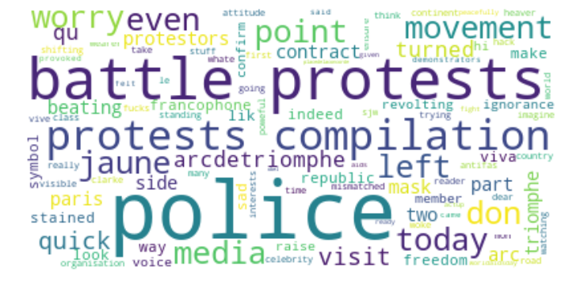

```python
from wordcloud import WordCloud
String=df['Tweet'].to_string()
plt.figure(figsize=(12,8))
wordcloud = WordCloud(max_font_size=60, max_words=100, background_color="white").generate(String)
plt.imshow(wordcloud, interpolation="bilinear")
plt.axis("off")
plt.show()
```

### Separation Positive and negative Tweets

```python
df_pos=df[df['Sentiment']=='Positive']
df_pos.sample(5)
```

|  | Tweet | Sentiment |
| --- | --- | --- |
| 37 | eyes us worry disappoint yellowvests s citizen... | Positive |
| 11 | poweful stuff going jaune | Positive |
| 4 | viva indeed | Positive |
| 17 | heaver continent watching country vive le | Positive |
| 36 | instant karma justice immanente | Positive |

```python
df_neg=df[df['Sentiment']=='Negative']
df_neg.sample(5)
```

|  | Tweet | Sentiment |
| --- | --- | --- |
| 32 | battle protests compilation | Negative |
| 5 | 1 3 battle protests compilation | Negative |
| 23 | mirza metro morning deep trouble jeered public... | Negative |
| 26 | france prelude major changes chaotic current a... | Negative |
| 15 | also antifas trying hack movement first time s... | Negative |

## WordCloud 2 (Positive )

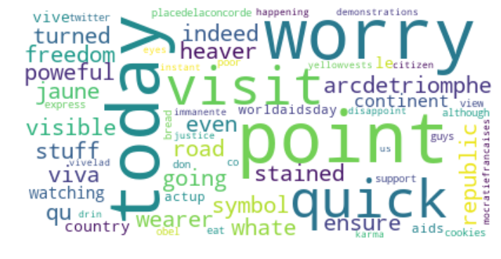

```python
from wordcloud import WordCloud
String=df_pos['Tweet'].to_string()
plt.figure(figsize=(12,8))
wordcloud = WordCloud(max_font_size=60, max_words=100, background_color="white").generate(String)
plt.imshow(wordcloud, interpolation="bilinear")
plt.axis("off")
plt.show()
```

## WordCloud 3 (Negative)

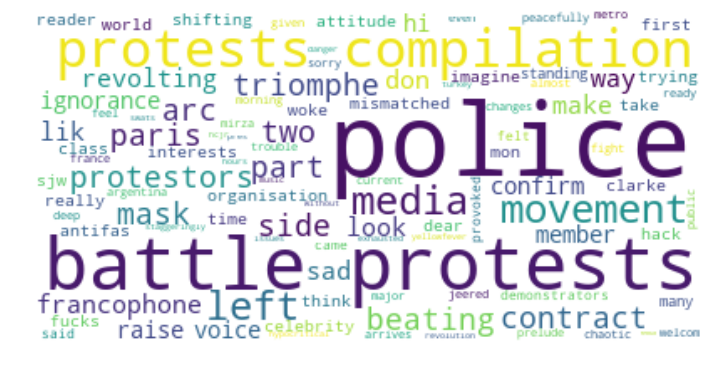

```python
from wordcloud import WordCloud
String=df_neg['Tweet'].to_string()
plt.figure(figsize=(12,8))
wordcloud = WordCloud(max_font_size=60, max_words=100, background_color="white").generate(String)
plt.imshow(wordcloud, interpolation="bilinear")
plt.axis("off")
plt.show()
```

# Feature extracting+Opinion Classification:

```python
import re
import nltk
from nltk.corpus import stopwords
from nltk.stem.porter import PorterStemmer
corpus = []
for i in range(0, 41):
    review = re.sub('[^a-zA-Z]', ' ', df['Tweet'][i])
    review = review.lower()
    review = review.split()
    ps = PorterStemmer()
    review = [ps.stem(word) for word in review if not word in set(stopwords.words('english'))]
    review = ' '.join(review)
    corpus.append(review)
```

```python
from sklearn.feature_extraction.text import CountVectorizer
cv = CountVectorizer(max_features = 1500)
X = cv.fit_transform(corpus).toarray()
y = df.iloc[:, 1].values
```

```python
from sklearn.model_selection import train_test_split
X_train, X_test, y_train, y_test = train_test_split(X, y, test_size = 0.20, random_state = 0)
```

```python
from sklearn.naive_bayes import GaussianNB
nb = GaussianNB()
nb.fit(X_train, y_train)
```

```
GaussianNB(priors=None)
```

```python
y_pred = nb.predict(X_test)
```

```python
from sklearn.metrics import confusion_matrix,accuracy_score
pd.crosstab(y_test, y_pred, rownames=['True'], colnames=['Predicted'])
```

| Predicted True | Negative | Positive |
| --- | --- | --- |
| Negative | 2 | 3 |
| Positive | 2 | 2 |

```python
accuracy_score(y_test, y_pred)
```

```
0.4444444444444444
```

```python
from sklearn.preprocessing import LabelEncoder
labelencoder_X = LabelEncoder()
y = labelencoder_X.fit_transform(y)

from sklearn.model_selection import train_test_split
X_train, X_test, y_train, y_test = train_test_split(X, y, test_size = 0.3, random_state = 0)
```

```python
from sklearn.svm import SVC
from sklearn.linear_model import LogisticRegression
```

```python
logreg = LogisticRegression()
svm = SVC(kernel="rbf",probability=True)

Classifiers = pd.DataFrame(data={'ClassifierName': ["Naive Bayes" ,"Logistic Regression","SVM"] ,'Classifier': [nb,logreg,svm]})
Classifiers
```

|  | ClassifierName | Classifier |
| --- | --- | --- |
| 0 | Naive Bayes | GaussianNB(priors=None, var_smoothing=1e-09) |
| 1 | Logistic Regression | LogisticRegression(C=1.0, class_weight=None, d... |
| 2 | SVM | SVC(C=1.0, cache_size=200, class_weight=None, ... |

```python
from sklearn.model_selection import cross_val_score
accuracy=[]
accuracies=[]
for index, row in Classifiers.iterrows():
    accuracies.append(round(cross_val_score(row['Classifier'], X, y, cv=10, scoring='accuracy').mean(),4))
    model = row['Classifier'] # select the model
    model.fit(X_train, y_train) # train the model
    y_pred=model.predict(X_test) # predict the test data
    accuracy.append(accuracy_score(y_test, y_pred))
```

[output not shown]

```python
Classifiers["Accuracy"]=accuracy
Classifiers["Accuracy(Cross Validated)"]=accuracies
Classifiers
```

|  | ClassifierName | Classifier | Accuracy | Accuracy(Cross Validated) |
| --- | --- | --- | --- | --- |
| 0 | Naive Bayes | GaussianNB(priors=None, var_smoothing=1e-09) | 0.538462 | 0.6250 |
| 1 | Logistic Regression | LogisticRegression(C=1.0, class_weight=None, d... | 0.615385 | 0.6883 |
| 2 | SVM | SVC(C=1.0, cache_size=200, class_weight=None, ... | 0.615385 | 0.6883 |